# 12: Missing data

Author

Thiago Cerqueira Silva

Incomplete solutions (only question 1.2 and 1.3)

```r
library(haven)
# create table
library(gtsummary)
# data wrangling and other functions
library(tidyverse)
# if you want to have a output similar to stata
library(tidylog)
#imputation
library(mice)

# Limit significant digits to 4, remove scientific notation (most of the time, scipen=999 removes all time)
options(digits = 4, scipen = 9)
```

# Q1.2

How many observations are there in total in the data set (use dis N or browse the data)?

```r
melb <- haven::read_dta("datasets/NCDS_melbourne.dta")
```

**Answer**

## How many observations are used in the complete case analysis?

```r
no_obs <- melb |>
  drop_na(noqual2,
          care,
          soch7,
          invbwt,
          mo_age) |>
  nrow()
melb <- melb |>
    mutate(
    care = as.factor(care),
    soch7 = as.factor(soch7),
    noqual2 = as.factor(noqual2),
    invbwt = as.numeric(invbwt)
  )
complete_case_model <- glm(noqual2~ care + soch7 +invbwt+ mo_age, family="binomial",
                           data=melb)
tbl_complete <- tbl_regression(complete_case_model,
               estimate_fun = purrr::partial(style_ratio, digits = 3)) |>
  modify_column_unhide(column = std.error)
tbl_complete
```

| **Characteristic** | **log(OR)** | **SE** | **95% CI** | **p-value** |
| --- | --- | --- | --- | --- |
| care |  |  |  |  |
| 0 | — | — | — |  |
| 1 | 1.093 | 0.157 | 0.788, 1.402 | <0.001 |
| soch7 |  |  |  |  |
| 0 | — | — | — |  |
| 1 | 0.947 | 0.046 | 0.858, 1.037 | <0.001 |
| invbwt | 123.9 | 14.2 | 96.23, 151.7 | <0.001 |
| mother's age at birth (centered around 28) | -0.007 | 0.004 | -0.015, 0.001 | 0.10 |

Abbreviations: CI = Confidence Interval, OR = Odds Ratio, SE = Standard Error

**Answer**

## What percentage of records are incomplete?

**Answer**

Under what assumption would inference from the complete records be valid? Do you believe this assumption?

**Answer**

The probability of a complete record is not associated with qualification status, given the covariates in the model. This may be plausible, since qualification status is observed at age 23. However, it is also possible that having data at age 23 may be related to educational qualifications, for example people with educational qualifications may be more likely to move away from home and drop out of the study.

## Use observed data to investigate this assumption. Does the assumption hold?

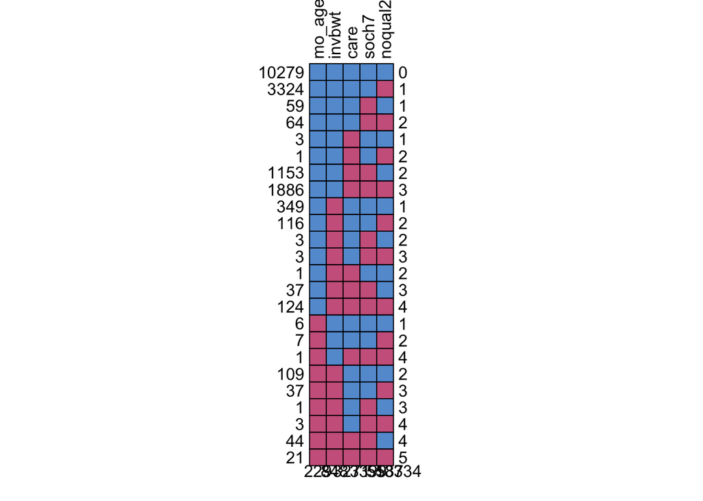

```
      mo_age invbwt care soch7 noqual2
10279      1      1    1     1       1     0
3324       1      1    1     1       0     1
59         1      1    1     0       1     1
64         1      1    1     0       0     2
3          1      1    0     1       1     1
1          1      1    0     1       0     2
1153       1      1    0     0       1     2
1886       1      1    0     0       0     3
349        1      0    1     1       1     1
116        1      0    1     1       0     2
3          1      0    1     0       1     2
3          1      0    1     0       0     3
1          1      0    0     1       1     2
37         1      0    0     0       1     3
124        1      0    0     0       0     4
6          0      1    1     1       1     1
7          0      1    1     1       0     2
1          0      1    0     0       0     4
109        0      0    1     1       1     2
37         0      0    1     1       0     3
1          0      0    1     0       1     3
3          0      0    1     0       0     4
44         0      0    0     0       1     4
21         0      0    0     0       0     5
         229    848 3271  3399    5587 13334
```

```r
# Select the variables you want to impute/missing info (algo including the outcome even if there is no missing in the outcome)
data.to.impute<- melb |>
  select(
    noqual2,
          care,
          soch7,
          invbwt,
          mo_age
  )
md.pattern(data.to.impute, plot = T, rotate.names = T)
```

```r
dt_indicator <- data.to.impute |>
  mutate(
    complete_case = if_else(
      !is.na(noqual2) &
        !is.na(soch7) &
      !is.na(invbwt) &
        !is.na(mo_age)&
      !is.na(care),
      0,
      1
    )
  )
mod_ind <- glm(complete_case ~ noqual2 + invbwt+mo_age, family = binomial, data=dt_indicator)

tbl_regression(mod_ind)
```

| **Characteristic** | **log(OR)** | **95% CI** | **p-value** |
| --- | --- | --- | --- |
| noqual2 |  |  |  |
| 0 | — | — |  |
| 1 | 0.17 | 0.04, 0.30 | 0.008 |
| invbwt | 32 | -4.5, 68 | 0.081 |
| mother's age at birth (centered around 28) | -0.02 | -0.03, -0.01 | 0.002 |

Abbreviations: CI = Confidence Interval, OR = Odds Ratio

## Can we determine the missingness mechanism from the dataset?

**Answer**

No, we have found evidence that missingness is associated with a number of the other variables in the dataset. We therefore have evidence against Missing Completely at Random (MCAR). However, we cannot from the observed data determine whether the values are Missing at Random (MAR) or Missing Not at Random (MNAR).

Take note this regression is only taking into account the observations with non-missing in the variables included

# Q 1.3

We will now use R’s multiple imputation In this example, we are going to impute missing values in more than one partially observed variable. Using the library mice (R has many other options to do MI). mice stands for Multivariate Imputation by Chained Equations

```r
glimpse(data.to.impute) # check the class of the variables ### Important
```

```
Rows: 17,631
Columns: 5
$ noqual2 <fct> NA, 1, 1, 0, 0, 1, 0, NA, NA, NA, 0, 1, 1, 1, 0, NA, 0, NA, 0,…
$ care    <fct> NA, NA, 0, 0, NA, 0, 0, 0, NA, 0, 0, 0, 0, 0, 0, 0, NA, NA, NA…
$ soch7   <fct> NA, NA, 1, 1, NA, 1, 0, 1, NA, 1, 0, 0, 0, 0, 0, 0, NA, NA, NA…
$ invbwt  <dbl> 0.008475, 0.008403, 0.008065, 0.010000, 0.007937, 0.010417, 0.…
$ mo_age  <dbl> -7, -7, -6, -8, -7, -11, -6, -10, -8, -9, -6, -6, -8, -8, -6, …
```

```r
# Run a dry imp (no iteration) to get a predction matrix
imp <- mice(data.to.impute, maxit=0)

# Extract predictorMatrix and methods of imputation

predM <- imp$predictorMatrix
meth <- imp$method

# you can exclude a variable from the imputation model using this
#predM[, c("invbwt")] <- 0
# you can change the imputation method for each variable like this
meth["invbwt"] <- "norm" #linear regression, the default value would be pmn -Predictive mean matching
meth["mo_age"] <- "norm" #linear regression
#  solution run 10 iterations and 15 datasets - usually you can get good results with 5 and 10 datasets and iterations (but it depends!)
# you can reduce it to save computation time (in your practical)
imp2 <- mice(data.to.impute, maxit = 10,  # equivalent to "burn"
             m= 15, #number of datasets
             predictorMatrix = predM,
             method = meth, print =  F,
             seed = 123)
```

```r
#Then fit the model to each imputed data set:
fit.ncds<-with(data=imp2,exp=glm(noqual2~ care + soch7 +invbwt+ mo_age, family="binomial"))
#summary(pool(fit.ncds))
tbl_imp <- tbl_regression(fit.ncds, estimate_fun = purrr::partial(style_ratio, digits = 3))|>
  modify_column_unhide(column = std.error)

tbl_merge(
  list(tbl_complete, tbl_imp),
  tab_spanner = c("**Complete Case**","**Imputation**")
)
```

| **Characteristic** | **Complete Case** **log(OR)** | **Complete Case** **SE** | **Complete Case** **95% CI** | **Complete Case** **p-value** | **Imputation** **log(OR)** | **Imputation** **SE** | **Imputation** **95% CI** | **Imputation** **p-value** |
| --- | --- | --- | --- | --- | --- | --- | --- | --- |
| care |  |  |  |  |  |  |  |  |
| 0 | — | — | — |  | — | — | — |  |
| 1 | 1.093 | 0.157 | 0.788, 1.402 | <0.001 | 1.199 | 0.153 | 0.891, 1.506 | <0.001 |
| soch7 |  |  |  |  |  |  |  |  |
| 0 | — | — | — |  | — | — | — |  |
| 1 | 0.947 | 0.046 | 0.858, 1.037 | <0.001 | 0.948 | 0.052 | 0.843, 1.053 | <0.001 |
| invbwt | 123.9 | 14.2 | 96.23, 151.7 | <0.001 | 26.27 | 7.58 | 11.22, 41.33 | <0.001 |
| mother's age at birth (centered around 28) | -0.007 | 0.004 | -0.015, 0.001 | 0.10 | -0.007 | 0.004 | -0.014, 0.001 | 0.078 |

Abbreviations: CI = Confidence Interval, OR = Odds Ratio, SE = Standard Error

## Solution

The probably reason of it not running is because the low variability of that variable, we can keep it but lets multiple by 100.

```r
data.to.impute<- melb |>
  select(
    noqual2,
          care,
          soch7,
          invbwt,
          mo_age
  ) |>
  mutate(
    invbwt_100 = 100*invbwt
  ) |>
  select(-invbwt) #remove original because collinear

# Run a dry imp (no iteration) to get a predction matrix
imp <- mice(data.to.impute, maxit=0)

# Extract predictorMatrix and methods of imputation

predM <- imp$predictorMatrix
meth <- imp$method

# We will need to say to only use invbwt_100 in the imputation

meth["mo_age"] <- "norm" #linear regression
meth["invbwt_100"] <- "norm" #linear regression
#  solution run 10 iterations and 15 datasets - usually you can get good results with 5 and 10 datasets and iterations (but it depends!)
# you can reduce it to save computation time (in your practical)
imp2 <- mice(data.to.impute, maxit = 10,  # equivalent to "burn"
             m= 15, #number of datasets
             predictorMatrix = predM,
             method = meth, print =  F,
             seed = 123)
```

```r
#Then fit the model to each imputed data set:
complete_case_model <- glm(noqual2~ care + soch7 +invbwt_100+ mo_age, family="binomial",
                           data=data.to.impute)
tbl_complete <- tbl_regression(complete_case_model,
               estimate_fun = purrr::partial(style_ratio, digits = 3)) |>
  modify_column_unhide(column = std.error)

fit.ncds<-with(data=imp2,exp=glm(noqual2~ care + soch7 +invbwt_100+ mo_age, family="binomial"))
#summary(pool(fit.ncds))
tbl_imp <- tbl_regression(fit.ncds, estimate_fun = purrr::partial(style_ratio, digits = 3))|>
  modify_column_unhide(column = std.error)

tbl_merge(
  list(tbl_complete, tbl_imp),
  tab_spanner = c("**Complete Case**","**Imputation**")
)
```

| **Characteristic** | **Complete Case** **log(OR)** | **Complete Case** **SE** | **Complete Case** **95% CI** | **Complete Case** **p-value** | **Imputation** **log(OR)** | **Imputation** **SE** | **Imputation** **95% CI** | **Imputation** **p-value** |
| --- | --- | --- | --- | --- | --- | --- | --- | --- |
| care |  |  |  |  |  |  |  |  |
| 0 | — | — | — |  | — | — | — |  |
| 1 | 1.093 | 0.157 | 0.788, 1.402 | <0.001 | 1.092 | 0.140 | 0.813, 1.371 | <0.001 |
| soch7 |  |  |  |  |  |  |  |  |
| 0 | — | — | — |  | — | — | — |  |
| 1 | 0.947 | 0.046 | 0.858, 1.037 | <0.001 | 0.947 | 0.045 | 0.857, 1.037 | <0.001 |
| invbwt_100 | 1.239 | 0.142 | 0.962, 1.517 | <0.001 | 1.173 | 0.127 | 0.916, 1.429 | <0.001 |
| mother's age at birth (centered around 28) | -0.007 | 0.004 | -0.015, 0.001 | 0.10 | -0.007 | 0.004 | -0.015, 0.001 | 0.075 |

Abbreviations: CI = Confidence Interval, OR = Odds Ratio, SE = Standard Error